# Week 5: Dimensionality reduction techniques

### The data

The data is from UNs Development programs Human Development Index (HDI) and Gender Inequality Index data frames. These two are combined together to be a data frame named “Human”. More information about the data [UN development programs: HDI](http://hdr.undp.org/en/content/human-development-index-hdi).

```r
# dependecies
library(dplyr); library(tidyr); library(dplyr); library(ggplot2)
library(stringr); library(FactoMineR); library(GGally); library(corrplot)
```

```r
# download human data
human <- read.csv("data/human.csv")
str(human)
```

```
## 'data.frame':    155 obs. of  9 variables:
##  $ X        : Factor w/ 155 levels "Afghanistan",..: 105 6 134 41 101 54 67 149 28 102 ...
##  $ Edu2.FM  : num  1.007 0.997 0.983 0.989 0.969 ...
##  $ Labo.FM  : num  0.891 0.819 0.825 0.884 0.829 ...
##  $ Edu.Exp  : num  17.5 20.2 15.8 18.7 17.9 16.5 18.6 16.5 15.9 19.2 ...
##  $ Life.Exp : num  81.6 82.4 83 80.2 81.6 80.9 80.9 79.1 82 81.8 ...
##  $ GNI      : Factor w/ 155 levels "1,123","1,228",..: 132 109 124 112 113 111 103 123 108 93 ...
##  $ Mat.Mor  : int  4 6 6 5 6 7 9 28 11 8 ...
##  $ Ado.Birth: num  7.8 12.1 1.9 5.1 6.2 3.8 8.2 31 14.5 25.3 ...
##  $ Parli.F  : num  39.6 30.5 28.5 38 36.9 36.9 19.9 19.4 28.2 31.4 ...
```

```r
dim(human)
```

```
## [1] 155   9
```

```r
head(human)
```

```
##             X   Edu2.FM   Labo.FM Edu.Exp Life.Exp    GNI Mat.Mor
## 1      Norway 1.0072389 0.8908297    17.5     81.6 64,992       4
## 2   Australia 0.9968288 0.8189415    20.2     82.4 42,261       6
## 3 Switzerland 0.9834369 0.8251001    15.8     83.0 56,431       6
## 4     Denmark 0.9886128 0.8840361    18.7     80.2 44,025       5
## 5 Netherlands 0.9690608 0.8286119    17.9     81.6 45,435       6
## 6     Germany 0.9927835 0.8072289    16.5     80.9 43,919       7
##   Ado.Birth Parli.F
## 1       7.8    39.6
## 2      12.1    30.5
## 3       1.9    28.5
## 4       5.1    38.0
## 5       6.2    36.9
## 6       3.8    36.9
```

The structure of the data shows the 9 variables. X is the row.names that are the names of the countries.

```r
# visualize human data
summary(human)
```

```
##            X          Edu2.FM          Labo.FM          Edu.Exp
##  Afghanistan:  1   Min.   :0.1717   Min.   :0.1857   Min.   : 5.40
##  Albania    :  1   1st Qu.:0.7264   1st Qu.:0.5984   1st Qu.:11.25
##  Algeria    :  1   Median :0.9375   Median :0.7535   Median :13.50
##  Argentina  :  1   Mean   :0.8529   Mean   :0.7074   Mean   :13.18
##  Armenia    :  1   3rd Qu.:0.9968   3rd Qu.:0.8535   3rd Qu.:15.20
##  Australia  :  1   Max.   :1.4967   Max.   :1.0380   Max.   :20.20
##  (Other)    :149
##     Life.Exp          GNI         Mat.Mor         Ado.Birth
##  Min.   :49.00   1,123  :  1   Min.   :   1.0   Min.   :  0.60
##  1st Qu.:66.30   1,228  :  1   1st Qu.:  11.5   1st Qu.: 12.65
##  Median :74.20   1,428  :  1   Median :  49.0   Median : 33.60
##  Mean   :71.65   1,458  :  1   Mean   : 149.1   Mean   : 47.16
##  3rd Qu.:77.25   1,507  :  1   3rd Qu.: 190.0   3rd Qu.: 71.95
##  Max.   :83.50   1,583  :  1   Max.   :1100.0   Max.   :204.80
##                  (Other):149
##     Parli.F
##  Min.   : 0.00
##  1st Qu.:12.40
##  Median :19.30
##  Mean   :20.91
##  3rd Qu.:27.95
##  Max.   :57.50
##
```

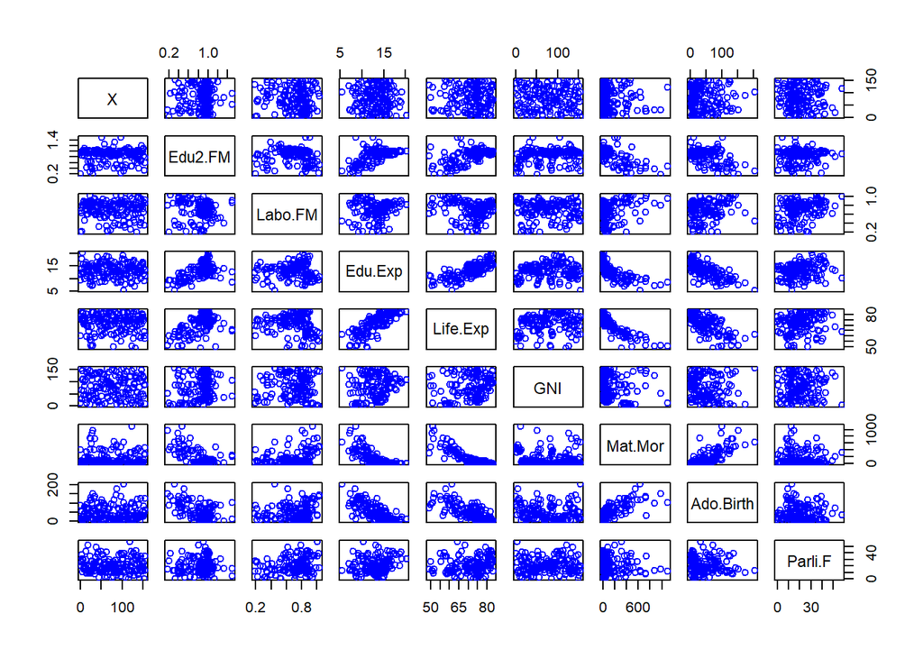

```r
plot(human, col="blue")
```

The summary of the variables shows the types of data they hold in. X is as described just a list of country names. Edu2FM is the ratio of secondary education and Labo.FM ratio of labour force participation. Life Exp shows the life expectancy in different nations how long on average people live approximately. Expected years of education (Edu.exp) shows that in minimum years people go to school.

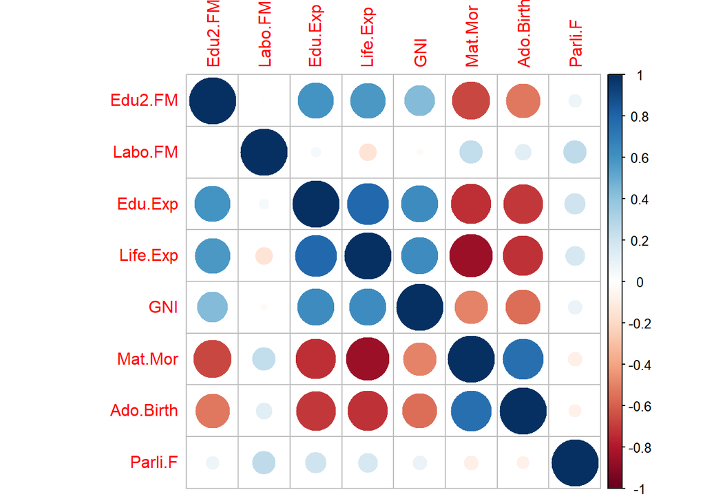

```r
human$GNI<- str_replace(human$GNI, pattern=",", replace ="") %>% as.numeric()
human_ <- select(human, -X)

cor(human_) %>% corrplot()
```

### Principal component analysis

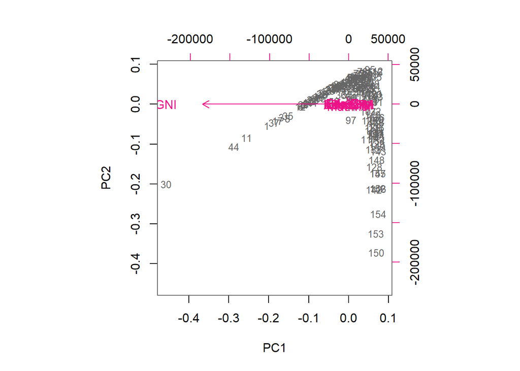

```r
#PCA on the not standardized human data.
pca_human <- prcomp(human_)
biplot(pca_human, choices = 1:2,cex=c(0.8,1),col = c("grey40", "deeppink2"))
```

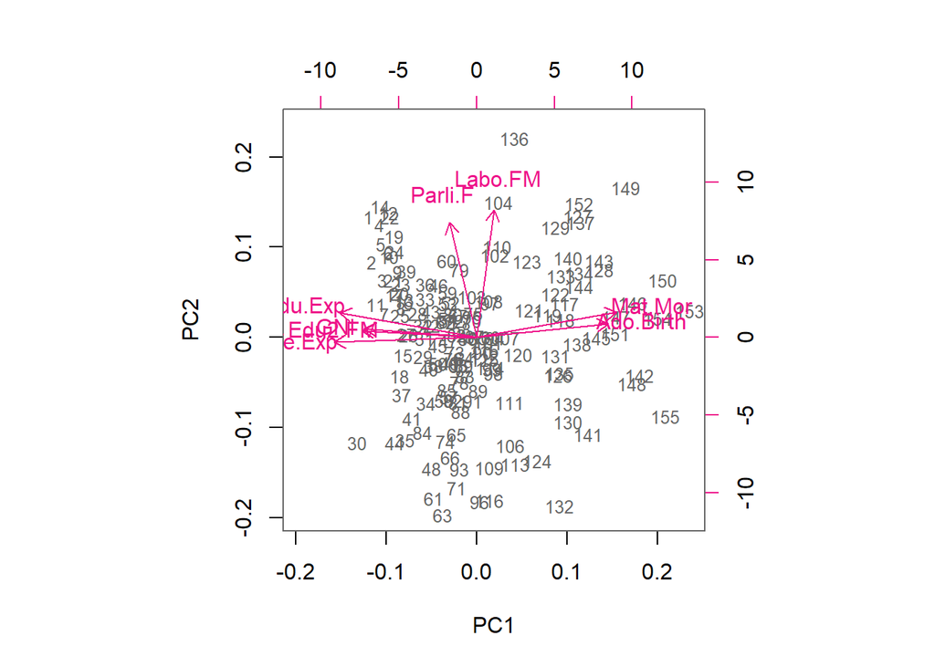

```r
#PCA on standardized/scaled variables
human_std <- scale(human_)
pca_human <- prcomp(human_std)
biplot(pca_human, choices = 1:2,cex=c(0.8,1),col = c("grey40", "deeppink2"))
```

Above here is the biplot of data frame after PCA. The frame has not been standardized yet, which is why it has a strange shape. PCA maximizes the variance between variables and therefore without standardizing they tend to pack tightly or show only observations of one variable clearly. Standardized data set variable means are scaled in the middle and the plot is much easier to read.

### Multiple Correspondence Analysis

A dataset “tea” from FactoMineR library. The data contains answers from poll on things related to tea time.

```r
data(tea)
str(tea)
```

```
## 'data.frame':    300 obs. of  36 variables:
##  $ breakfast       : Factor w/ 2 levels "breakfast","Not.breakfast": 1 1 2 2 1 2 1 2 1 1 ...
##  $ tea.time        : Factor w/ 2 levels "Not.tea time",..: 1 1 2 1 1 1 2 2 2 1 ...
##  $ evening         : Factor w/ 2 levels "evening","Not.evening": 2 2 1 2 1 2 2 1 2 1 ...
##  $ lunch           : Factor w/ 2 levels "lunch","Not.lunch": 2 2 2 2 2 2 2 2 2 2 ...
##  $ dinner          : Factor w/ 2 levels "dinner","Not.dinner": 2 2 1 1 2 1 2 2 2 2 ...
##  $ always          : Factor w/ 2 levels "always","Not.always": 2 2 2 2 1 2 2 2 2 2 ...
##  $ home            : Factor w/ 2 levels "home","Not.home": 1 1 1 1 1 1 1 1 1 1 ...
##  $ work            : Factor w/ 2 levels "Not.work","work": 1 1 2 1 1 1 1 1 1 1 ...
##  $ tearoom         : Factor w/ 2 levels "Not.tearoom",..: 1 1 1 1 1 1 1 1 1 2 ...
##  $ friends         : Factor w/ 2 levels "friends","Not.friends": 2 2 1 2 2 2 1 2 2 2 ...
##  $ resto           : Factor w/ 2 levels "Not.resto","resto": 1 1 2 1 1 1 1 1 1 1 ...
##  $ pub             : Factor w/ 2 levels "Not.pub","pub": 1 1 1 1 1 1 1 1 1 1 ...
##  $ Tea             : Factor w/ 3 levels "black","Earl Grey",..: 1 1 2 2 2 2 2 1 2 1 ...
##  $ How             : Factor w/ 4 levels "alone","lemon",..: 1 3 1 1 1 1 1 3 3 1 ...
```

[output cut: 22 more lines]

```r
dim(tea)
```

```
## [1] 300  36
```

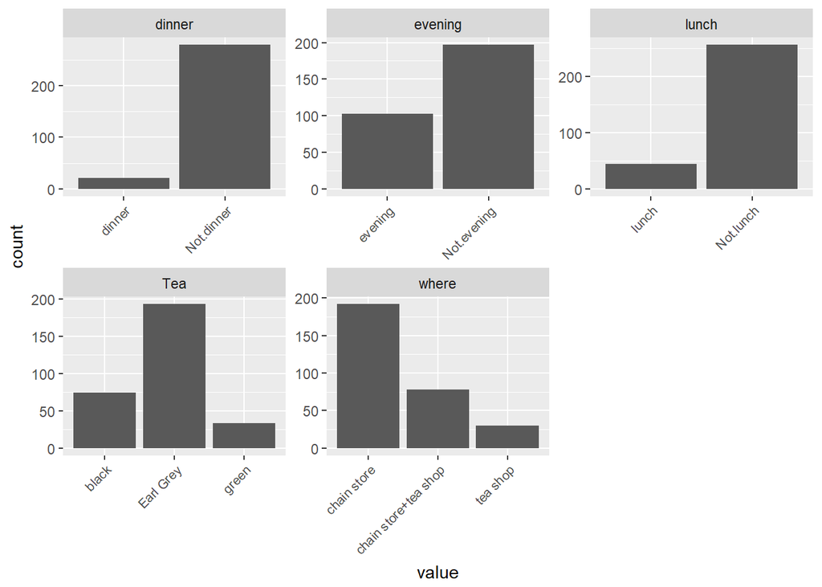

```r
keep_columns<- c("Tea", "evening", "dinner", "lunch", "where")
tea_time<- select(tea, one_of(keep_columns))

gather(tea_time) %>% ggplot(aes(value)) + facet_wrap("key", scales = "free")  +geom_bar() +theme(axis.text.x = element_text(angle = 45, hjust = 1, size = 8))
```

Multiple Correspondence Analysis with variables Tea, Evening, Dinner, Lunch and Where.

```r
mca <- MCA(tea_time, graph = FALSE)
summary(mca)
```

```
##
## Call:
## MCA(X = tea_time, graph = FALSE)
##
##
## Eigenvalues
##                        Dim.1   Dim.2   Dim.3   Dim.4   Dim.5   Dim.6
## Variance               0.275   0.221   0.209   0.204   0.185   0.157
## % of var.             19.619  15.761  14.926  14.574  13.242  11.226
## Cumulative % of var.  19.619  35.380  50.306  64.880  78.121  89.347
##                        Dim.7
## Variance               0.149
## % of var.             10.653
## Cumulative % of var. 100.000
##
## Individuals (the 10 first)
##                Dim.1    ctr   cos2    Dim.2    ctr   cos2    Dim.3    ctr
## 1           |  0.108  0.014  0.013 | -0.612  0.566  0.427 | -0.508  0.412
## 2           |  0.108  0.014  0.013 | -0.612  0.566  0.427 | -0.508  0.412
## 3           |  0.514  0.321  0.080 |  0.398  0.239  0.048 |  0.585  0.545
## 4           |  0.864  0.907  0.247 | -0.052  0.004  0.001 |  0.738  0.868
## 5           | -0.323  0.126  0.159 |  0.148  0.033  0.033 | -0.186  0.055
## 6           |  0.864  0.907  0.247 | -0.052  0.004  0.001 |  0.738  0.868
## 7           |  0.028  0.001  0.002 | -0.302  0.138  0.242 | -0.034  0.002
## 8           | -0.242  0.071  0.051 | -0.162  0.040  0.023 | -0.661  0.697
## 9           | -0.176  0.038  0.037 | -0.348  0.183  0.145 |  0.678  0.734
## 10          | -0.446  0.241  0.123 | -0.208  0.065  0.027 |  0.051  0.004
##               cos2
## 1            0.294 |
## 2            0.294 |
## 3            0.104 |
## 4            0.180 |
## 5            0.053 |
## 6            0.180 |
## 7            0.003 |
## 8            0.378 |
## 9            0.552 |
## 10           0.002 |
##
## Categories (the 10 first)
```

[output cut: 15 more lines]

```
## evening       8.678 |  -0.230   1.731   0.028  -2.870 |
## Not.evening  -8.678 |   0.120   0.905   0.028   2.870 |
## dinner        2.593 |   1.639  18.005   0.202   7.777 |
## Not.dinner   -2.593 |  -0.123   1.355   0.202  -7.777 |
## lunch        10.980 |  -0.045   0.029   0.000  -0.325 |
## Not.lunch   -10.980 |   0.008   0.005   0.000   0.325 |
## chain store  -2.737 |  -0.498  15.165   0.440 -11.472 |
##
## Categorical variables (eta2)
##               Dim.1 Dim.2 Dim.3
## Tea         | 0.297 0.222 0.318 |
## evening     | 0.190 0.252 0.028 |
## dinner      | 0.313 0.022 0.202 |
## lunch       | 0.210 0.403 0.000 |
## where       | 0.364 0.204 0.496 |
```

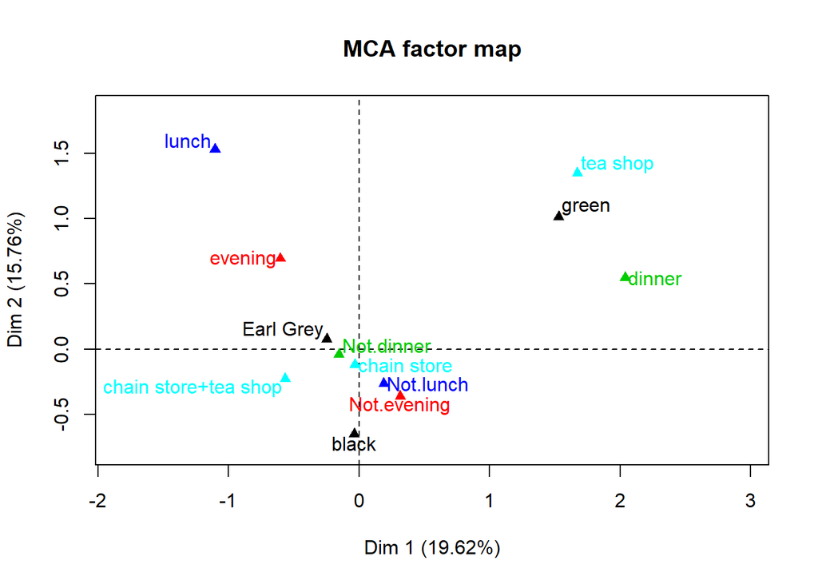

```r
plot(mca, invisible=c("ind"), habillage = "quali")
```

Three variables stand from the crowd: dinner, tea shop and green tea. They don’t come close to the dimensions and seems correlate with each other. All the other variables gather around the origo, except lunch.